# Data acquaintance for Mediterranean dataset (MEData)

Shira Salingré

2023-02-02

# Introduction

MEData is a dataset of underwater fish census surveys conducted along the Mediterranean sea. The dataset includes environmental variables, as well as conservation information regarding MPAs.

```r
medata <- read_rds("data/medata.Rds")
```

# Variables

[output not shown]

- *Data types: num = decimal number; fct = factor; lgl = logical

# Overview

```r
summary(medata)
```

```
##        data.origin       country         season           lon
##  azz_asi     : 3875   Italy  :13380   autumn:18275   Min.   : 1.159
##  azz_malt    : 4179   Israel :10324   spring: 5464   1st Qu.: 8.349
##  Belmaker    :25679   Greece : 6424   summer:21015   Median :15.751
##  Sala - PEW  : 9111   France : 3617                  Mean   :19.375
##  Periklis_MER: 1910   Croatia: 3508                  3rd Qu.:34.073
##                       Spain  : 2959                  Max.   :35.076
##                       (Other): 4542
##       lat                 site           trans      unique_trans_id
##  Min.   :32.42   asinara_add: 3033   Min.   :   1   Length:44754
##  1st Qu.:34.97   gdor       : 2941   1st Qu.: 239   Class :character
##  Median :36.74   achziv     : 2900   Median :1432   Mode  :character
##  Mean   :37.63   shikmona   : 2373   Mean   :1232
##  3rd Qu.:41.05   habonim    : 2110   3rd Qu.:2000
##  Max.   :44.94   malta      : 1582   Max.   :2392
##                  (Other)    :29815   NA's   :35
##  protection      enforcement   total.mpa.ha        size.notake
##  Mode :logical   0   :18648   Min.   :    15.95   Min.   :    0.0
##  FALSE:18648     1   : 7780   1st Qu.:   191.00   1st Qu.:  167.7
##  TRUE :25784     2   : 9745   Median :   785.00   Median :  519.2
##  NA's :322       3   : 8259   Mean   :  5487.56   Mean   : 2950.9
##                  NA's:  322   3rd Qu.:  2375.00   3rd Qu.: 2651.0
##                               Max.   :207000.00   Max.   :15000.0
##                               NA's   :16093       NA's   :19618
##   yr.creation    age.reserve.yr      depth            tmean
##  2002   : 8879   1      : 4030   Min.   : 1.000   Min.   :16.78
##  1962   : 3617   55     : 3617   1st Qu.: 5.200   1st Qu.:18.66
##  1960   : 3508   57     : 3508   Median :10.000   Median :20.09
##  1986   : 3126   9      : 3193   Mean   : 9.365   Mean   :20.08
##  2004   : 2941   32     : 3126   3rd Qu.:11.000   3rd Qu.:22.11
##  (Other):11316   (Other):15913   Max.   :29.000   Max.   :23.00
##  NA's   :11367   NA's   :11367   NA's   :16376    NA's   :1366
##     sal_mean        pp_mean         species               sp.n
##  Min.   :33.99   Min.   :0.0004   Length:44754       Min.   :    0.00
##  1st Qu.:37.67   1st Qu.:0.0005   Class :character   1st Qu.:    1.00
##  Median :37.89   Median :0.0008   Mode  :character   Median :    1.00
##  Mean   :38.08   Mean   :0.0029                      Mean   :   16.64
##  3rd Qu.:38.79   3rd Qu.:0.0062                      3rd Qu.:    4.00
##  Max.   :39.25   Max.   :0.0096                      Max.   :10000.00
##  NA's   :1366    NA's   :1366
##    sp.length                family        exotic          FoodTroph
##  Min.   :  0.00   Labridae     :19351   Mode :logical   Min.   :2.000
##  1st Qu.:  8.00   Sparidae     :10028   FALSE:41157     1st Qu.:3.240
##  Median : 10.00   Serranidae   : 4182   TRUE :3549      Median :3.340
##  Mean   : 11.66   Pomacentridae: 2956   NA's :48        Mean   :3.271
##  3rd Qu.: 15.00   Siganidae    : 2403                   3rd Qu.:3.500
##  Max.   :150.00   Scaridae     : 1341                   Max.   :4.500
##  NA's   :842      (Other)      : 4493                   NA's   :827
##   FoodSeTroph           a               b
##  Min.   :0.0000   Min.   :0.001   Min.   :2.429
##  1st Qu.:0.4100   1st Qu.:0.011   1st Qu.:2.892
##  Median :0.4300   Median :0.015   Median :3.042
##  Mean   :0.4228   Mean   :0.017   Mean   :3.017
##  3rd Qu.:0.4700   3rd Qu.:0.020   3rd Qu.:3.122
##  Max.   :0.9100   Max.   :0.062   Max.   :3.482
##  NA's   :827      NA's   :8444    NA's   :8444
```

```r
skimr::skim(medata)
```

Data summary

| Name | medata |
| --- | --- |
| Number of rows | 44754 |
| Number of columns | 27 |
| _______________________ |  |
| Column type frequency: |  |
| character | 2 |
| factor | 8 |
| logical | 2 |
| numeric | 15 |
| ________________________ |  |
| Group variables | None |

**Variable type: character**

| skim_variable | n_missing | complete_rate | min | max | empty | n_unique | whitespace |
| --- | --- | --- | --- | --- | --- | --- | --- |
| unique_trans_id | 0 | 1 | 11 | 55 | 0 | 2269 | 0 |
| species | 0 | 1 | 8 | 28 | 0 | 135 | 0 |

**Variable type: factor**

| skim_variable | n_missing | complete_rate | ordered | n_unique | top_counts |
| --- | --- | --- | --- | --- | --- |
| data.origin | 0 | 1.00 | FALSE | 5 | Bel: 25679, Sal: 9111, azz: 4179, azz: 3875 |
| country | 0 | 1.00 | FALSE | 9 | Ita: 13380, Isr: 10324, Gre: 6424, Fra: 3617 |
| season | 0 | 1.00 | FALSE | 3 | sum: 21015, aut: 18275, spr: 5464 |
| site | 0 | 1.00 | FALSE | 84 | asi: 3033, gdo: 2941, ach: 2900, shi: 2373 |
| enforcement | 322 | 0.99 | FALSE | 4 | 0: 18648, 2: 9745, 3: 8259, 1: 7780 |
| yr.creation | 11367 | 0.75 | FALSE | 16 | 200: 8879, 196: 3617, 196: 3508, 198: 3126 |
| age.reserve.yr | 11367 | 0.75 | FALSE | 20 | 1: 4030, 55: 3617, 57: 3508, 9: 3193 |
| family | 0 | 1.00 | FALSE | 41 | Lab: 19351, Spa: 10028, Ser: 4182, Pom: 2956 |

**Variable type: logical**

| skim_variable | n_missing | complete_rate | mean | count |
| --- | --- | --- | --- | --- |
| protection | 322 | 0.99 | 0.58 | TRU: 25784, FAL: 18648 |
| exotic | 48 | 1.00 | 0.08 | FAL: 41157, TRU: 3549 |

**Variable type: numeric**

| skim_variable | n_missing | complete_rate | mean | sd | p0 | p25 | p50 | p75 | p100 | hist |
| --- | --- | --- | --- | --- | --- | --- | --- | --- | --- | --- |
| lon | 0 | 1.00 | 19.38 | 11.59 | 1.16 | 8.35 | 15.75 | 34.07 | 35.08 | ▅▇▂▅▇ |
| lat | 0 | 1.00 | 37.63 | 3.85 | 32.42 | 34.97 | 36.74 | 41.05 | 44.94 | ▇▇▃▅▅ |
| trans | 35 | 1.00 | 1231.51 | 866.81 | 1.00 | 239.00 | 1432.00 | 2000.00 | 2392.00 | ▇▁▅▅▇ |
| total.mpa.ha | 16093 | 0.64 | 5487.56 | 20976.18 | 15.95 | 191.00 | 785.00 | 2375.00 | 207000.00 | ▇▁▁▁▁ |
| size.notake | 19618 | 0.56 | 2950.91 | 5209.93 | 0.00 | 167.70 | 519.20 | 2651.00 | 15000.00 | ▇▁▁▁▂ |
| depth | 16376 | 0.63 | 9.37 | 5.36 | 1.00 | 5.20 | 10.00 | 11.00 | 29.00 | ▆▇▂▁▁ |
| tmean | 1366 | 0.97 | 20.08 | 2.02 | 16.78 | 18.66 | 20.09 | 22.11 | 23.00 | ▅▆▇▂▇ |
| sal_mean | 1366 | 0.97 | 38.08 | 0.86 | 33.99 | 37.67 | 37.89 | 38.79 | 39.25 | ▁▁▁▇▇ |
| pp_mean | 1366 | 0.97 | 0.00 | 0.00 | 0.00 | 0.00 | 0.00 | 0.01 | 0.01 | ▇▂▁▃▁ |
| sp.n | 0 | 1.00 | 16.64 | 152.29 | 0.00 | 1.00 | 1.00 | 4.00 | 10000.00 | ▇▁▁▁▁ |
| sp.length | 842 | 0.98 | 11.66 | 7.69 | 0.00 | 8.00 | 10.00 | 15.00 | 150.00 | ▇▁▁▁▁ |
| FoodTroph | 827 | 0.98 | 3.27 | 0.40 | 2.00 | 3.24 | 3.34 | 3.50 | 4.50 | ▁▁▇▁▁ |
| FoodSeTroph | 827 | 0.98 | 0.42 | 0.13 | 0.00 | 0.41 | 0.43 | 0.47 | 0.91 | ▁▁▇▁▁ |
| a | 8444 | 0.81 | 0.02 | 0.01 | 0.00 | 0.01 | 0.01 | 0.02 | 0.06 | ▅▇▁▁▁ |
| b | 8444 | 0.81 | 3.02 | 0.14 | 2.43 | 2.89 | 3.04 | 3.12 | 3.48 | ▁▁▇▆▁ |

## Countries

Data was collected from 9 countries:

```r
medata %>% distinct(country) %>% arrange(.$country) %>% print(n = Inf)
```

```
## # A tibble: 9 × 1
##   country
##   <fct>
## 1 Croatia
## 2 France
## 3 Greece
## 4 Israel
## 5 Italy
## 6 Malta
## 7 Spain
## 8 Turkey
## 9 Cyprus
```

## Species

Dataset withholds 124 species

```r
medata %>% distinct(species) %>% arrange(.$species) %>% count()
```

```
## # A tibble: 1 × 1
##       n
##   <int>
## 1   135
```

```r
# proper species
medata %>% distinct(species) %>% arrange(.$species) %>%
  filter(!c(grepl("dae", species) | grepl(".spp", species))) %>%
  print(n = Inf)
```

```
## # A tibble: 124 × 1
##     species
##     <chr>
##   1 Abudefduf.saxatilis
##   2 Anthias.anthias
##   3 Apogon.imberbis
##   4 Atherina.boyeri
##   5 Balistes.capriscus
##   6 Belone.belone
##   7 Boops.boops
##   8 Bothus.podas
##   9 Caranx.crysos
##  10 Cheilodipterus.novemstriatus
##  11 Chelon.labrosus
##  12 Chromis.chromis
```

[output cut: 112 more lines]

**NOTE**: There are 135 taxa in the dataset but some are not species but genus (Atherina.spp, Symphodus.spp etc.) or family (Labridae, Clupeidae, Belonidae etc.).

# Methods

## Data collection

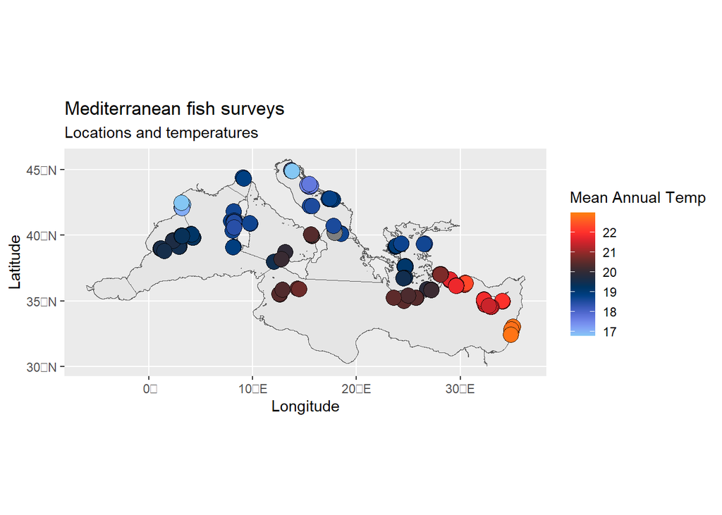

Figure 1. Survey sites and temperatures (in degrees celsius).

The sampling protocol is described in [Frid Ori, et al., 2022](https://doi.org/10.12681/mms.26423).

## Data acquired from other resources

**Environmental data** (temperature, salinity and primary production) were acquired from [Bio-ORACLE](http://http://www.bio-oracle.org) using `sdmpredictors` package.

**Layers**:

- tmean = “BO_sstmean”
- sal_mean = “BO2_salinitymean_ss”
- pp_mean = “BO2_ppmean_ss”

(See [“R/bio-oracle extraction code.R”](https://github.com/belmaker-lab/medata/blob/master/R/bio-oracle%20extraction%20code.R) for full extraction code).

## Data wrangling notes

- Linosa and kornati did not have specific coordinates, therefore, an approximate location (lat-lon) was attached to it. If your analysis requires fine-detail for the location, you might want to omit these locations.
- Data from source `asinara_add` site are presence-absence only.

# Transformations

Many analyses require species matrix where each row is a site and each column is a species.

Here’s the code to create such matrix with this dataset:

```r
# Create a species matrix with where rows are transects and columns are species
# (id_cols can be minimised but I keep it for explicitness)
med_mat <- medata %>%
  pivot_wider(id_cols = c(data.origin, country, season, lon, lat, site, trans, unique_trans_id, protection, enforcement, total.mpa.ha, size.notake, yr.creation, age.reserve.yr, depth, tmean, sal_mean, pp_mean),
              names_from = species, values_from = sp.n,
              values_fn = function(x) sum(x, na.rm = T), values_fill = 0)

# Convert the abundance data to pseudo presence-absence
pres_abs_mat <- med_mat
first_species <- which(colnames(med_mat) == "Atherina.boyeri")
pres_abs_mat[first_species:ncol(pres_abs_mat)] <- ifelse(pres_abs_mat[first_species:ncol(pres_abs_mat)] > 0, 1, 0)
```

Just pay attention that here there is also metadata in the left columns (until the first species). Some ecological anaylses require the data to be a real matrix (only made of one type of data - the abundance of each species), and in this case just make sure you separate the meta-data from the species matrix.

# View the data

## Species richness

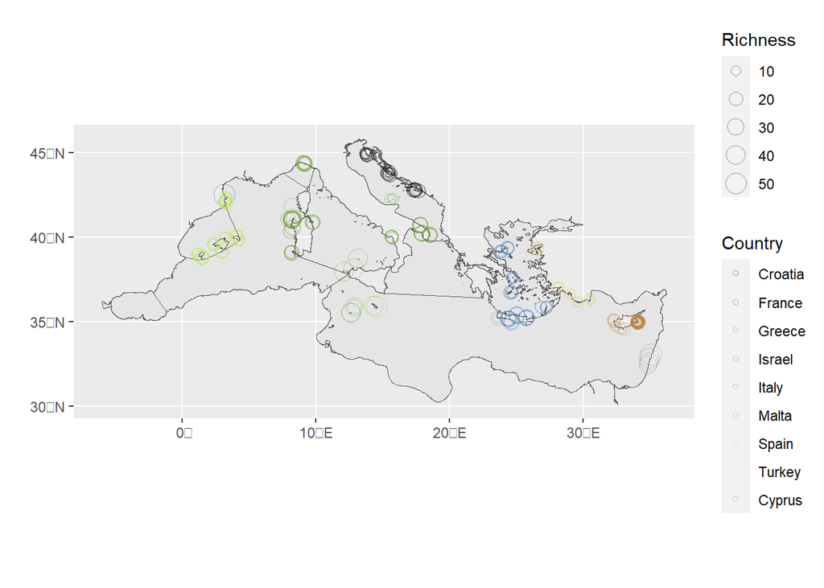

```r
col_scale <- fishualize::fish(n = 9, option = "Thalassoma_pavo")
medata %>%
  group_by(country, lon, lat) %>%
  distinct(species) %>% summarise(richness = n()) %>%
  ggplot() +
  geom_sf(data = med_map$geometry) +
  geom_point(aes(x = lon, y = lat, size = richness, col = country), pch = 21, alpha = 0.4) +
  scale_colour_manual(values = col_scale, name = "Country") +
  labs(x = "", y = "", size = "Richness")
```

## Lessepsian migrants

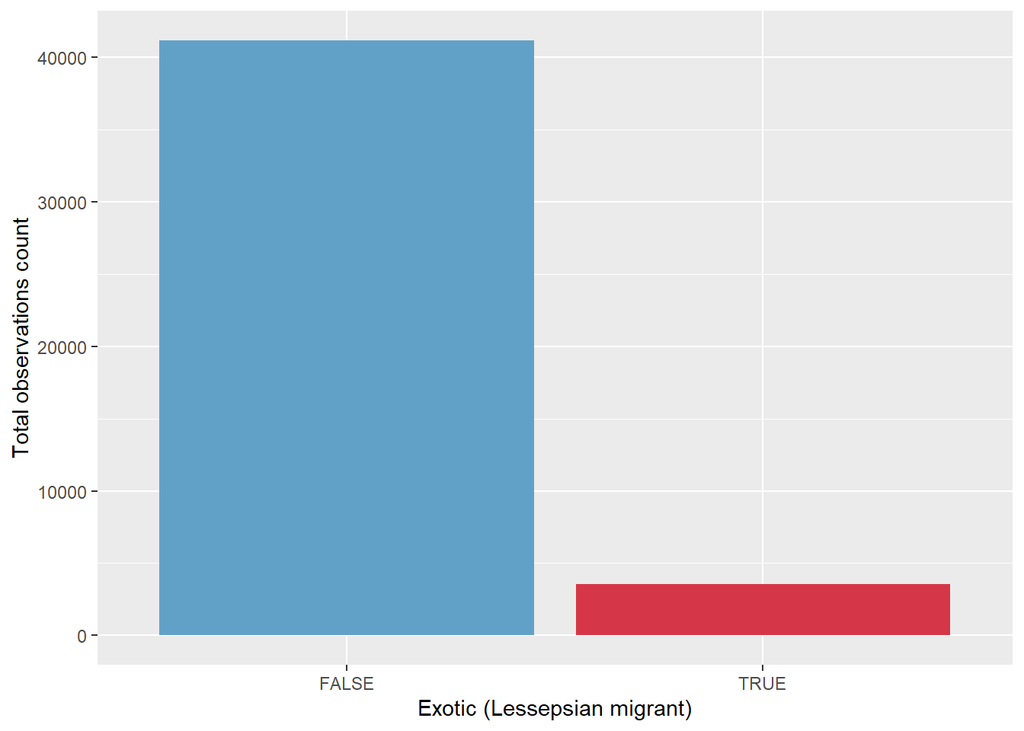

```r
medata %>% filter(!is.na(exotic)) %>%
  ggplot() + aes(x = exotic) + geom_bar(fill = c("#62a1c7", "#d53748")) +
  labs(x = "Exotic (Lessepsian migrant)", y = "Total observations count")
```

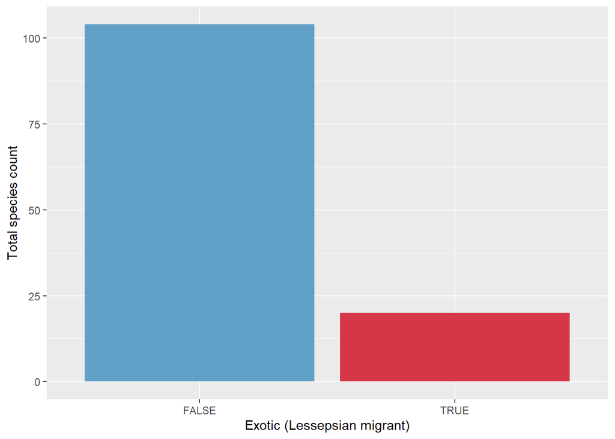

```r
medata %>% filter(!is.na(exotic)) %>% distinct(species, exotic) %>%
  ggplot() + aes(x = exotic) + geom_bar(fill = c("#62a1c7", "#d53748")) +
  labs(x = "Exotic (Lessepsian migrant)", y = "Total species count")
```

# References

Froese, R. and D. Pauly. Editors. 2021.FishBase. World Wide Web electronic publication. www.fishbase.org, (06/2021)

Boettiger C, Temple Lang D, Wainwright P (2012). “rfishbase: exploring, manipulating and visualizing FishBase data from R.” Journal of Fish Biology

Assis J, Tyberghein L, Bosch S, Heroen V, SerrÃ£o E, De Clerck O, Tittensor D (2018). Bio-ORACLE v2.0: Extending marine data layers for bioclimatic modelling.” *Global Ecology and Biogeography*, *27*(3),277-284. doi: 10.1111/geb.12693 (https://doi.org/10.1111/geb.12693).

Tyberghein L, Heroen V, Pauly K, Troupin C, Mineur F, De Clerck O (2012). Bio-ORACLE: a global environmental dataset for marine speciesdistribution modelling." *Global Ecology and Biogeography*, *21*(2),272-281. doi: 10.1111/j.1466-8238.2011.00656.x (https://doi.org/10.1111/j.1466-8238.2011.00656.x).